# EDAV Project 2 - PCA Analysis

Team Noname

March 7, 2016

### 1. Global flood records dataset analysis

As a preliminar analysis, we decided to visualize the relationship between flood between the flood characteristics and the number of people displaced in the Global Flood record database. Firstly, we visualized the distribution of each variable:

- Severity:

[figure not shown]

- Affected area:

[figure not shown]

- Duration:

[figure not shown]

- Number displaced:

[figure not shown]

Except for severity, other variables appear skewed, so we log-transformed them and then centered and scaled them. Next, we performed multiple linear regression with "displaced" as dependent variable and other three variables as independent variables. This model seems to explain ~19% of number of people displaced.

```
     1 .  regress std_log_displaced severity std_log_affected std_log_duration

            Source |       SS       df       MS              Number of obs =    3034
      -------------+------------------------------           F(  3,  3030) =  239.40
             Model |  581.158345     3  193.719448           Prob > F      =  0.0000
          Residual |  2451.84164  3030  .809188658           R-squared     =  0.1916
      -------------+------------------------------           Adj R-squared =  0.1908
             Total |  3032.99998  3033  .999999994           Root MSE      =  .89955

      ----------------------------------------------------------------------------------
      std_log_displa~d |      Coef.   Std. Err.      t    P>|t|     [95% Conf. Interval]
      -----------------+----------------------------------------------------------------
              severity |   .1240879   .0421517     2.94   0.003     .0414392    .2067367
      std_log_affected |   .1801437   .0188169     9.57   0.000     .1432485     .217039
      std_log_duration |   .3070196   .0184443    16.65   0.000     .2708549    .3431842
                 _cons |  -.2192853   .0545864    -4.02   0.000    -.3263154   -.1122551
      ----------------------------------------------------------------------------------
```

Next, we proceeded to check if the assumptions for linear regression hold:

- Assumption of normality of residuals appears satisfied.

[figure not shown]

- Assumption of homoscedasticity of residuals appears satisfied.

[figure not shown]

- No evidence of significant collinearity (VIF <10).

  ```
   2 .  vif

        Variable |       VIF       1/VIF
    -------------+----------------------
    std_log_du~n |      1.30    0.766732
    std_log_af~d |      1.29    0.774600
        severity |      1.06    0.945632
    -------------+----------------------
        Mean VIF |      1.22
  ```

- Assumption of linearity appears satisfied.

[figure not shown]

### 4. Perform principal components analysis on "affected", "severity", and "duration"

Estimate principal components.

```
     3 .  pca severity std_log_affected std_log_duration

      Principal components/correlation                  Number of obs    =      4312
                                                        Number of comp.  =         3
                                                        Trace            =         3
          Rotation: (unrotated = principal)             Rho              =    1.0000

          --------------------------------------------------------------------------
             Component |   Eigenvalue   Difference         Proportion   Cumulative
          -------------+------------------------------------------------------------
                 Comp1 |      1.58649      .701889             0.5288       0.5288
                 Comp2 |      .884599      .355685             0.2949       0.8237
                 Comp3 |      .528914            .             0.1763       1.0000
          --------------------------------------------------------------------------

      Principal components (eigenvectors)

          ----------------------------------------------------------
              Variable |    Comp1     Comp2     Comp3 | Unexplained
          -------------+------------------------------+-------------
              severity |   0.4067    0.9125    0.0443 |           0
          std_log_af~d |   0.6412   -0.3196    0.6977 |           0
          std_log_du~n |   0.6508   -0.2554   -0.7150 |           0
          ----------------------------------------------------------
```

Component 1 explains ~53% of variance, so compute score of that component (pc1) and regress on that alone.

As seen, model R2 is similar to earlier model with separate terms for "magnitude" and "duration " (R2 ~0.18 versus ~0.19).

```
     4 .  regress std_log_displaced pc1

            Source |       SS       df       MS              Number of obs =    3034
      -------------+------------------------------           F(  1,  3032) =  660.36
             Model |  542.436732     1  542.436732           Prob > F      =  0.0000
          Residual |  2490.56325  3032  .821425874           R-squared     =  0.1788
      -------------+------------------------------           Adj R-squared =  0.1786
             Total |  3032.99998  3033  .999999994           Root MSE      =  .90633

      ------------------------------------------------------------------------------
      std_log_di~d |      Coef.   Std. Err.      t    P>|t|     [95% Conf. Interval]
      -------------+----------------------------------------------------------------
               pc1 |   .3320503   .0129215    25.70   0.000     .3067145    .3573861
             _cons |  -.0640488   .0166419    -3.85   0.000    -.0966794   -.0314183
      ------------------------------------------------------------------------------
```

Regression model with "pc1" appears to be equal to or superior R2 to regression models with "du ration" alone or "magnitude" alone.

```
     5 .  regress std_log_displaced severity

            Source |       SS       df       MS              Number of obs =    3034
      -------------+------------------------------           F(  1,  3032) =   67.93
             Model |  66.4655162     1  66.4655162           Prob > F      =  0.0000
          Residual |  2966.53446  3032  .978408464           R-squared     =  0.0219
      -------------+------------------------------           Adj R-squared =  0.0216
             Total |  3032.99998  3033  .999999994           Root MSE      =  .98915

      ------------------------------------------------------------------------------
      std_log_di~d |      Coef.   Std. Err.      t    P>|t|     [95% Conf. Interval]
      -------------+----------------------------------------------------------------
          severity |   .3714916   .0450724     8.24   0.000      .283116    .4598672
             _cons |  -.4636299   .0590483    -7.85   0.000    -.5794086   -.3478511
      ------------------------------------------------------------------------------


     6 . regress std_log_displaced std_log_affected

            Source |       SS       df       MS              Number of obs =    3034
      -------------+------------------------------           F(  1,  3032) =  374.66
             Model |  333.563804     1  333.563804           Prob > F      =  0.0000
          Residual |  2699.43618  3032  .890315361           R-squared     =  0.1100
      -------------+------------------------------           Adj R-squared =  0.1097
             Total |  3032.99998  3033  .999999994           Root MSE      =  .94357

      ----------------------------------------------------------------------------------
      std_log_displa~d |      Coef.   Std. Err.      t    P>|t|     [95% Conf. Interval]
      -----------------+----------------------------------------------------------------
      std_log_affected |   .3362418   .0173714    19.36   0.000     .3021809    .3703027
                 _cons |  -.0289544   .0171955    -1.68   0.092    -.0626704    .0047615
      ----------------------------------------------------------------------------------


     7 . regress std_log_displaced std_log_duration

            Source |       SS       df       MS              Number of obs =    3034
      -------------+------------------------------           F(  1,  3032) =  590.56
             Model |  494.448928     1  494.448928           Prob > F      =  0.0000
          Residual |  2538.55105  3032  .837252986           R-squared     =  0.1630
      -------------+------------------------------           Adj R-squared =  0.1627
             Total |  3032.99998  3033  .999999994           Root MSE      =  .91502

      ----------------------------------------------------------------------------------
      std_log_displa~d |      Coef.   Std. Err.      t    P>|t|     [95% Conf. Interval]
      -----------------+----------------------------------------------------------------
      std_log_duration |   .3992275   .0164281    24.30   0.000     .3670161    .4314389
                 _cons |   -.063597   .0168168    -3.78   0.000    -.0965705   -.0306235
      ----------------------------------------------------------------------------------
```

Check assumptions of linear regression for model with principal component alone:

- Assumption of normality of residuals appears satisfied.

[figure not shown]

- Assumption of homoscedasticity of residuals appears satisfied.

[figure not shown]

- No evidence of significant collinearity (VIF <10).

  ```
   8 .  vif

        Variable |       VIF       1/VIF
    -------------+----------------------
             pc1 |      1.00    1.000000
    -------------+----------------------
        Mean VIF |      1.00
  ```

- Assumption of linearity appears satisfied.

[figure not shown]

Finally, we visually assessed the relationship between multiple flood characteristics and the number of people displaced. Such a visualization would be difficult to perform with traditional linear regression in the presence of multiple independent variables.

[figure not shown]

Principal components analysis allowed dimension reduction to one dimension, thereby allowing direct visualization. Prediction using one principal component was equally predictive as regression limited to one tr aditional independent variable and additionally allowed direct visualization between predictor and outcome. However, the disad vantage of this approach is that the first principal component is more difficult to conceptually understand than a traditional p redictor such as severity.

### 2. Global flood record analysis by continent

As a second part, the Global flood record dataset was collapsed into a per-continent view, to view a summary of the most relevant predictors by continent:

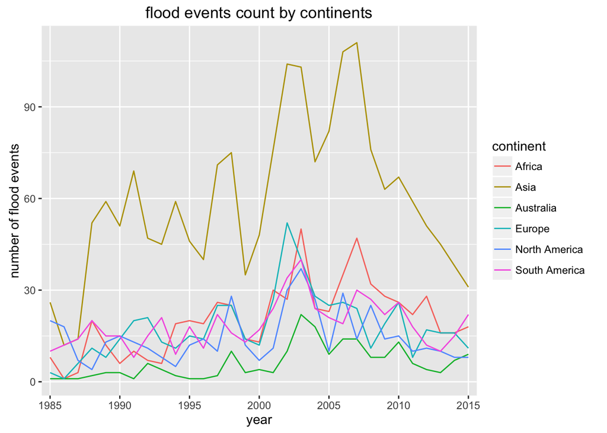

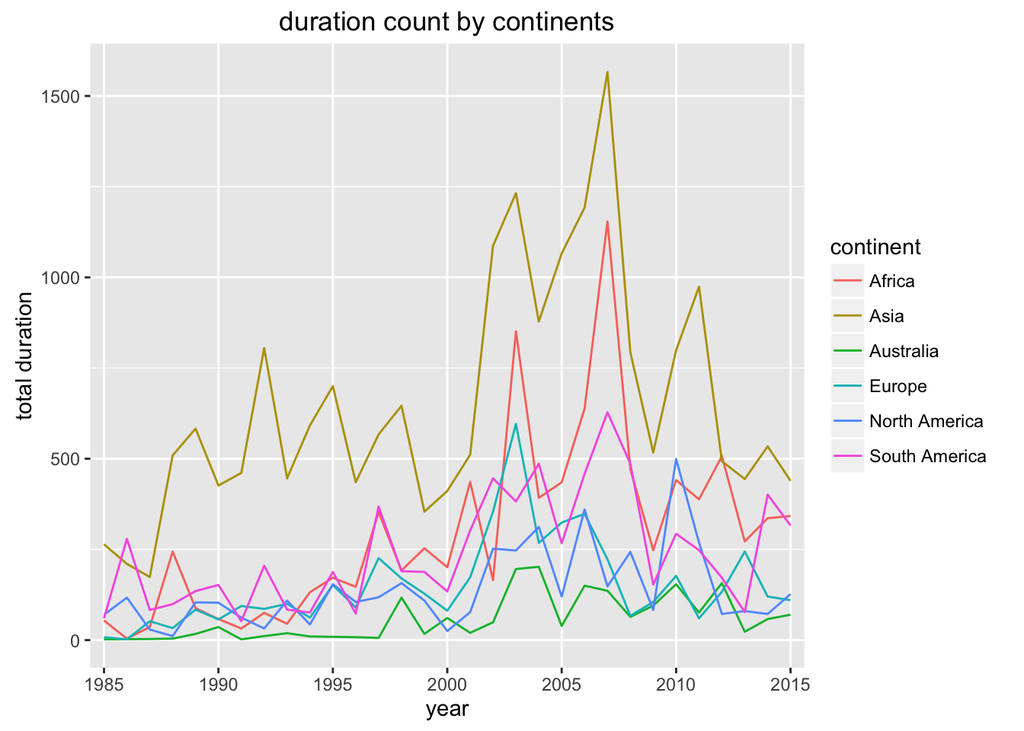

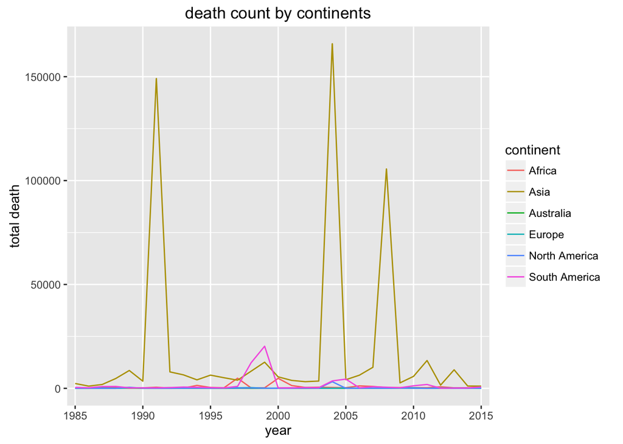

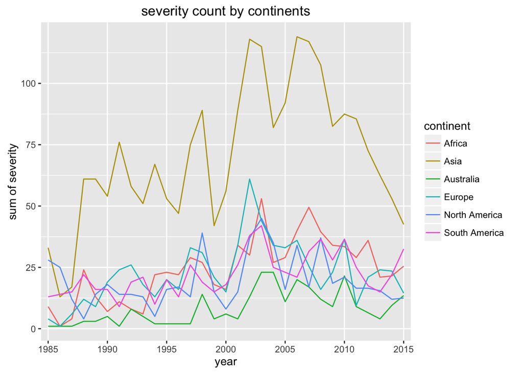

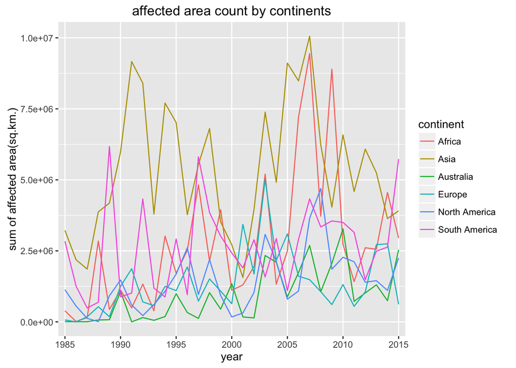

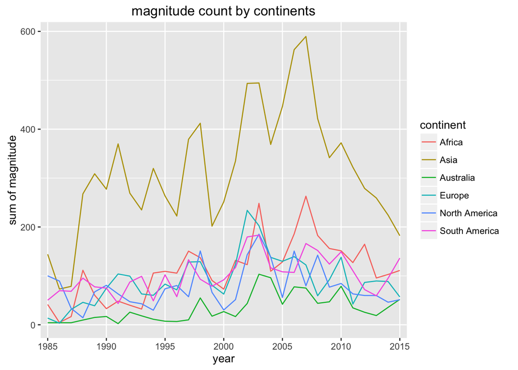

### 3.Principal component analysis on the floods in the UK during 1990

We decided to subset the data and focus our attention in five flood events that occurred in the United Kingdom during 1990. We came up with these events after slicing the Global Floods data over time and generating an animation that allowed us to perfectly tackle big and isolated flood events over time. The interactive animation is shown below:

[interactive chart not shown]

### Transforming the data

```
##      Began Ended
## 3837  7663  7666
## 3845  7605  7607
## 3856  7583  7584
## 3924  7361  7363
## 3930  7330  7345
```

Once the phi data for each flood event days was located, we came up with the following protocol for having five relevant datrices, one per flood:

Each dataset is consituted by a ribbon subset of the phi data, ranging over all longitudes (in order to preserve the direction-shifting pattern of pressure waves) but only ranging on latitudes higher than 45N and lower than 60N. This contitutes a grid of 7x144=1008 cells for every day. In order to keep our datasets as matrices, we used the *as.vector()* function to create a vector collapsing the 1008 grid cells for every day.

Since R can’t handle matrices with high dimensionality with *princomp()*, and we also wanted to capture the varying effect of pressure levels over time in several time dimensions, we decided to subset observations in the following way:

1. For every flood event, we designed an *interval()* function that, given the start and end dates of a specific flood event, returns a date interval ranging from 30 days before the start of the flood to 30 days after the day of the flood. That is, for a 4-day flood it returns a 64-day interval, and for a 16-day flood, it returns a 76-day interval.
2. Every interval is analized on all years ranging from 19 years before the year of the flood, to 19 years after the flood. That is, 39 years including the flood year. Combining the protocol we get that, for a 4-day flood event we have a 64-day period times 39 years = 2496 observations. Similarly, for a 16-day flood we have a 76-day period times 39 years = 2964 observations.

Hence, the final dimensions of the 5 matrices vary around 2418 and 2964 rows and all of them have 1008 columns (one per grid cell), as detailed below:

```
## [1] 2496 1008
```

```
## [1] 2457 1008
```

```
## [1] 2418 1008
```

```
## [1] 2457 1008
```

```
## [1] 2964 1008
```

Once we have the slices for each flood event, we ran PCA on them. Below are displayed the plots showing the variance that each component explains:

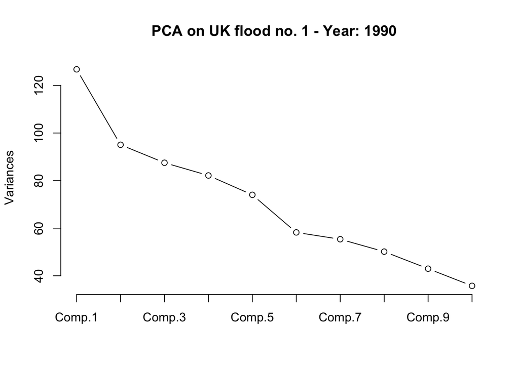

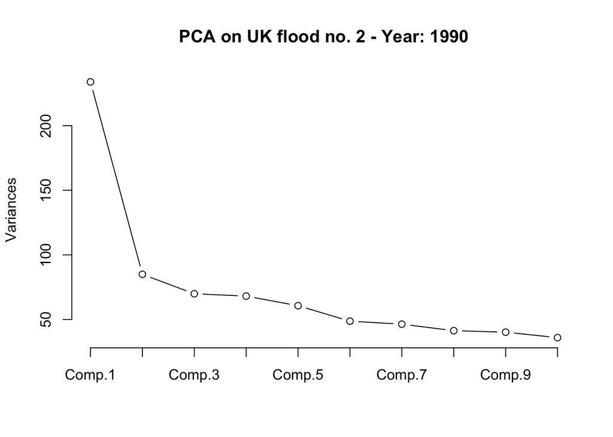

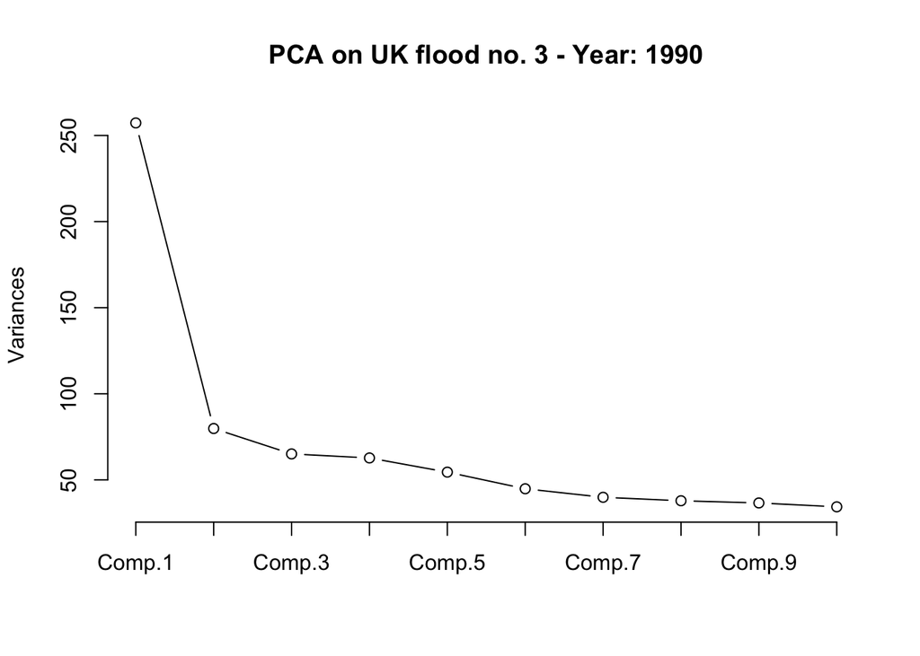

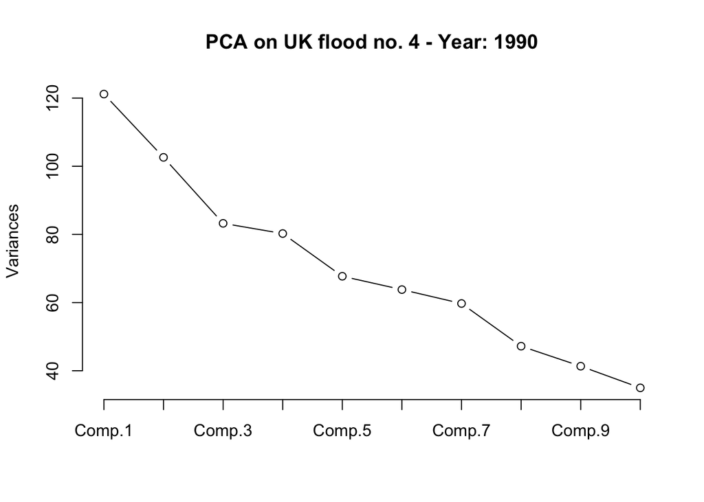

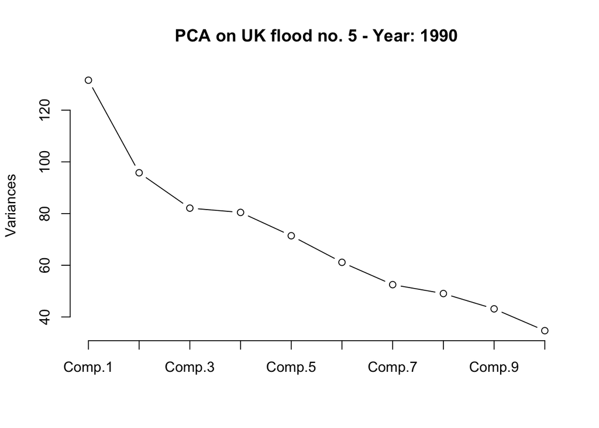